# Ejercicio 1. Ocho apellidos españoles

Diego Paniagua

12/01/2015

### Enunciado:

*Obtén shapefiles de, p.e., provincias españolas (el INE los proporciona). Luego, obtén datos de algún tipo de estadística asociada a dichas entidades (población, tasa de desempleo, etc.). Con esos dos elementos, crea un SpatialPolygonsDataFrame y represéntalos gráficamente. Trata de hacerlo reproduciblemente (¿con R MarkDown?).*

### Resolución del ejercicio:

La idea para este ejercicio la obtuve googleando. Acabé en la siguiente URL:

https://envejecimientoenred.wordpress.com/2014/07/16/ocho-apellidos-espanoles/

La idea principal del estudio y citándolo textualemente es: “Los ocho apellidos más frecuentes (como primer apellido) son por este orden: García, González, Rodríguez, Fernández, López, Martínez, Sánchez y Pérez”

En ella, entre otras cosas exponen la distribución por provincias de estos apellidos, la tabla en concreto en la que figuran estos datos y que me ha servido para el ejercicio ha sido la siguiente:

https://envejecimientoenred.files.wordpress.com/2014/07/tabla-2-porcentaje-en-cada-provincia-del-conjunto-de-los-ocho-apellidos-mc3a1s-frecuentes-de-espac3b1a-2013.jpg

A partir de esa imagen, con un programa OCR extraje los datos a texto y modificandolo ligeramente lo almacené en porcentajeapellidos.csv.

Por otro lado, como dice el enunciado, descargué el shapefile del mapa de España de la web del INE.

```r
#Cargo el paquete rgdal y establezco el directorio de trabajo

library(rgdal)
```

```r
#Cargo el fichero shape del mapa de España por provincias, descargado del INE.

provincias <- readOGR(dsn = "provincias_shp", "Provincias",stringsAsFactors=FALSE)
```

```
## with 52 features and 3 fields
## Feature type: wkbPolygon with 2 dimensions
```

```r
#Compruebo su clase
class(provincias)
```

```
## [1] "SpatialPolygonsDataFrame"
## attr(,"package")
## [1] "sp"
```

```r
#Un objeto de la clase S4 tiene "slots", que son las variables del objeto. Muestro sus slots.
slotNames(provincias)
```

```
## [1] "data"        "polygons"    "plotOrder"   "bbox"        "proj4string"
```

```r
#El slot más importante de este tipo de clases es "data". Lo muestro.
provincias@data
```

```
##    COD_PROV                 NOM_PROV COD_CCAA
## 0        01           ARABA/\xc1LAVA       17
## 1        02                 ALBACETE       06
## 2        03         ALACANT/ALICANTE       19
## 3        04               ALMER\xcdA       01
## 4        05                 \xc1VILA       07
## 5        06                  BADAJOZ       10
## 6        07            ILLES BALEARS       03
## 7        08                BARCELONA       08
## 8        09                   BURGOS       07
## 9        10               C\xc1CERES       10
## 10       11                 C\xc1DIZ       01
## 11       12 CASTELL\xd3/CASTELL\xd3N       19
## 12       13              CIUDAD REAL       06
## 13       14               C\xd3RDOBA       01
```

[output cut: 38 more lines]

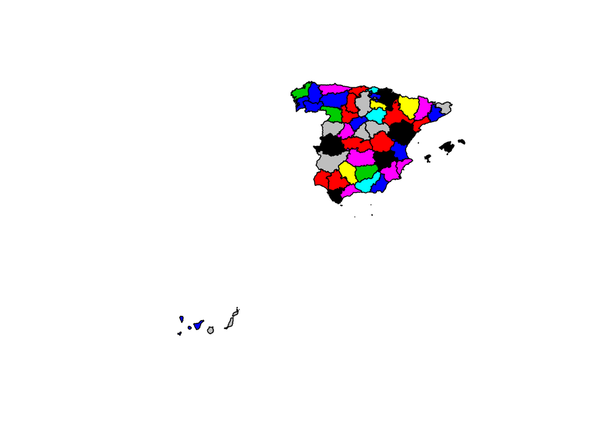

```r
#Vamos con el fichero de datos. Le hago una serie de transformaciones para adaptarlo a mis necesidades:

#Cargo el fichero de datos. En el figura el nombre de la provincia, el dato del % de apellidos y el código de la provincia.
apellidos<-read.table(file="porcentajeapellidos.csv",sep=";")

#Como el data frame del mapa tiene los códigos de provincia del 1 al 10 con dos digitos, se los añado al de apellidos
paso1<-do.call("paste", c('0',apellidos[c('V3')],sep=""))
apellidos$V3<-substr(paso1, nchar(paso1)-1, nchar(paso1))

#Uno los dataframes para añadir la columna del %
union<-merge(x = provincias@data, y = apellidos, by.x = "COD_PROV", by.y="V3",all = TRUE)

#Elimino la columna que no me sirve
union$V1<- NULL

#Asigno la unión a una nueva variable mas descriptiva
mapacondatos<-union
#Renombro la nueva variable
names(mapacondatos)[names(mapacondatos)=="V2"] <- "PORC.8APELLIDOS"
#Elimino la fila que tiene NA (venian datos de España)
mapacondatos<-mapacondatos[complete.cases(mapacondatos),]
#Elimino el % de los datos
mapacondatos$PORC.8APELLIDOS<-gsub("%", "", as.character(mapacondatos$PORC.8APELLIDOS) )
#Cambio las comas por puntos
mapacondatos$PORC.8APELLIDOS<-gsub(",", ".", as.character(mapacondatos$PORC.8APELLIDOS) )
#Paso a numerico el %
mapacondatos<-transform(mapacondatos, PORC.8APELLIDOS = as.numeric(PORC.8APELLIDOS))


#Reasigno los datos ya con la columna del % incluida
provincias@data<-mapacondatos
#Pinto el mapa, el col=... le indica un vector de colores, por lo que las provincias con un valor similar deberían tener un color similar
plot(provincias, col = provincias$PORC.8APELLIDOS)
```